# Analysis of growth curve outputs

Saaz and Alyssah

2026-09-15

Dose-response curves for IC50 calculation adapted from Babrham Bioinformatics tutorial: https://www.youtube.com/watch?v=yZRvzYsWqJw Made after “Combined_outputs_analysis_June15”. As a result, outlier batch J9 is already removed. Changes made to input file (addition of replicates column) to accommodate dose-response code. NOTE - APR 2025 - figures modified to only look at control strains.

This code deals with each CNV strain, one at a time.

```r
library(ggplot2)
library(readxl)
library(forcats)
library(drc)
library(tidyverse)
library(broom)
library(dplyr)

All_growthcurve_output = read_excel("combinedoutputsJul9Jul14.xlsx")


Pilot_media="N-lim"
#All_growthcurve_output=All_growthcurve_output[All_growthcurve_output$Media!="YPGly",]
```

To follow the tutorial mentioned above, this will be calculated for each CNV strain vs all control strains. That must be done by for loop. But the result of one strain will be shown individually here.

Initial setup data for use in IC50 calculation: 1. Combine all controls from all batches (based on “Combined_outputs_analysis_June15” showing similarity across batches). 2. Create new variable including replicate 3. Plot the data (each replicate visible)

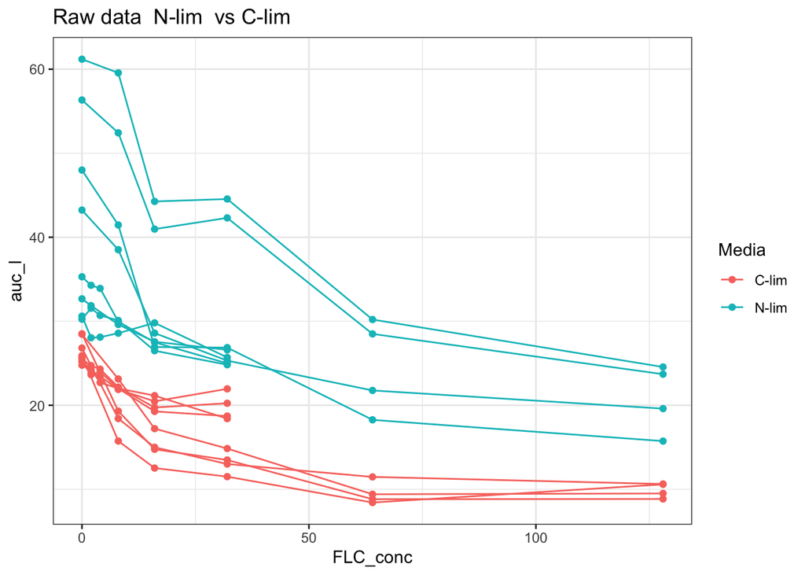

```r
Mod_growthcurve_output=All_growthcurve_output[All_growthcurve_output$Media=="C-lim",]

Pilot_output=All_growthcurve_output[All_growthcurve_output$Media==paste(Pilot_media),]

Mod_growthcurve_output=rbind(Mod_growthcurve_output,Pilot_output)

Mod_growthcurve_output$Newsample=paste(Mod_growthcurve_output$Media,"_",Mod_growthcurve_output$Bio_rep,"_",Mod_growthcurve_output$Tech_rep)

ggplot(Mod_growthcurve_output,aes(x=FLC_conc, y=auc_l, group=Newsample, colour=Media)) + geom_line() + geom_point() + theme_bw() + ggtitle(paste("Raw data ", Pilot_media, " vs C-lim"))
```

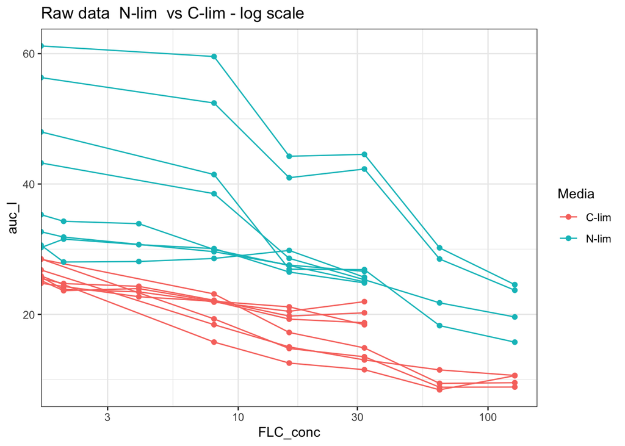

```r
ggplot(Mod_growthcurve_output,aes(x=FLC_conc, y=auc_l, group=Newsample, colour=Media)) + geom_line() + geom_point() + theme_bw() + scale_x_log10() + ggtitle(paste("Raw data ", Pilot_media, " vs C-lim - log scale"))
```

```r
#ADDED APR 2025
# Controlonly1=Mod_growthcurve_output[Mod_growthcurve_output$Type=="Control",]
#
# ggplot(Controlonly1,aes(x=FLC_conc, y=r, group=Newsample, colour=Type)) + geom_line() + geom_point() + theme_bw() + scale_x_log10() + ggtitle("Control media - log scale x axis")
```

Find mean grwoth rate for each type (CNV or control) in each FLC conc, and then find the max of these. Normalise all rates by the relevant max (for control and CNV separately). Tidy and plot normalised data.

```r
Mod_growthcurve_output %>%
  group_by(FLC_conc,Media) %>%
  summarise(
    max_response=mean(auc_l)
  ) %>%
  ungroup() %>%
  arrange(desc(max_response)) %>%
  group_by(Media) %>%
  slice(1) %>%
  ungroup() %>%
  dplyr::select(-FLC_conc) -> max_rates
```

```
## `summarise()` has regrouped the output.
## ℹ Summaries were computed grouped by FLC_conc and Media.
## ℹ Output is grouped by FLC_conc.
## ℹ Use `summarise(.groups = "drop_last")` to silence this message.
## ℹ Use `summarise(.by = c(FLC_conc, Media))` for per-operation grouping
##   (`?dplyr::dplyr_by`) instead.
```

```r
max_rates
```

```
## # A tibble: 2 × 2
##   Media max_response
##   <chr>        <dbl>
## 1 C-lim         26.4
## 2 N-lim         42.2
```

```r
Mod_growthcurve_output %>%
  left_join(max_rates) %>%
  mutate(
    norm_auc=100*auc_l/max_response
  ) %>%
  dplyr::select(FLC_conc,Media,Newsample,auc_l,norm_auc) -> drc_norm
drc_norm
```

```
## # A tibble: 95 × 5
##    FLC_conc Media Newsample     auc_l norm_auc
##       <dbl> <chr> <chr>         <dbl>    <dbl>
##  1        0 C-lim C-lim _ 1 _ 1  25.5     96.7
##  2        0 C-lim C-lim _ 1 _ 2  25.2     95.6
##  3        0 C-lim C-lim _ 2 _ 1  25.7     97.6
##  4        0 C-lim C-lim _ 2 _ 2  24.8     94.0
##  5        2 C-lim C-lim _ 1 _ 1  24.7     93.8
##  6        2 C-lim C-lim _ 1 _ 2  23.6     89.7
##  7        2 C-lim C-lim _ 2 _ 1  23.8     90.4
##  8        2 C-lim C-lim _ 2 _ 2  24.3     92.1
##  9        4 C-lim C-lim _ 1 _ 1  24.3     92.2
## 10        4 C-lim C-lim _ 1 _ 2  24.0     90.9
## # ℹ 85 more rows
```

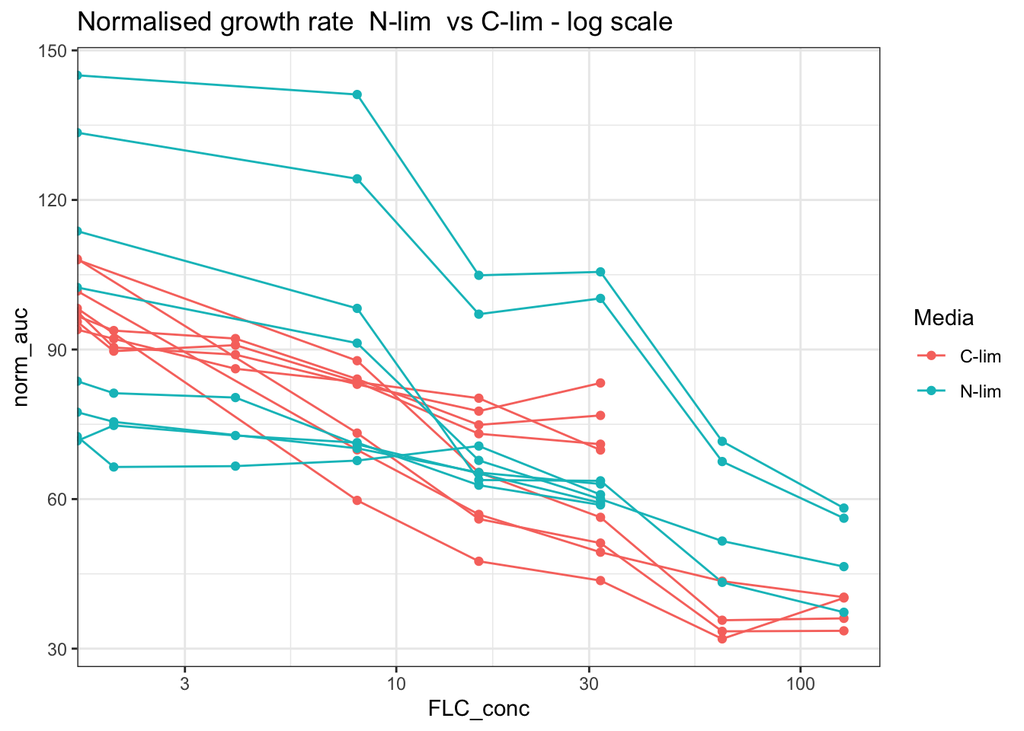

```r
ggplot(drc_norm,aes(x=FLC_conc, y=norm_auc, group=Newsample, colour=Media)) + geom_line() + geom_point() + theme_bw() + scale_x_log10() + ggtitle(paste("Normalised growth rate ", Pilot_media, " vs C-lim - log scale"))
```

adding error bar to mean data, and plotting it

```r
drc_norm %>%
  group_by(FLC_conc,Media) %>%
  dplyr::summarise(
    sem = sd(norm_auc)/sqrt(n()),
    response=mean(norm_auc)
  ) -> drc_per_condition
```

```
## `summarise()` has regrouped the output.
## ℹ Summaries were computed grouped by FLC_conc and Media.
## ℹ Output is grouped by FLC_conc.
## ℹ Use `summarise(.groups = "drop_last")` to silence this message.
## ℹ Use `summarise(.by = c(FLC_conc, Media))` for per-operation grouping
##   (`?dplyr::dplyr_by`) instead.
```

```r
drc_per_condition
```

```
## # A tibble: 16 × 4
## # Groups:   FLC_conc [8]
##    FLC_conc Media    sem response
##       <dbl> <chr>  <dbl>    <dbl>
##  1        0 C-lim  1.93     100
##  2        0 N-lim 10.1      100
##  3        2 C-lim  0.924     91.5
##  4        2 N-lim  3.05      74.5
##  5        4 C-lim  1.31      89.5
##  6        4 N-lim  3.98      73.2
##  7        8 C-lim  3.38      78.1
##  8        8 N-lim  9.85      91.9
##  9       16 C-lim  4.20      66.5
## 10       16 N-lim  5.85      74.7
## 11       32 C-lim  5.10      62.7
## 12       32 N-lim  6.91      71.4
## 13       64 C-lim  2.57      36.2
## 14       64 N-lim  6.66      58.5
## 15      128 C-lim  1.65      37.5
## 16      128 N-lim  4.81      49.5
```

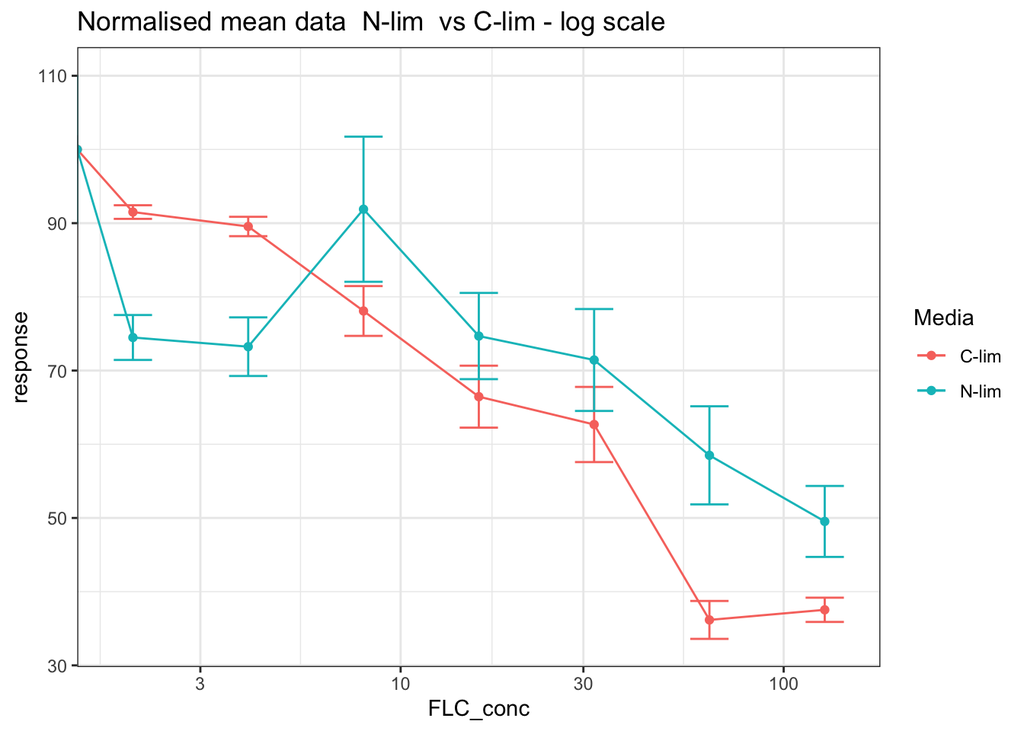

```r
ggplot(drc_per_condition,aes(x=FLC_conc, y=response, ymin=response-sem, ymax=response+sem, colour=Media)) + geom_line() + geom_point() +  geom_errorbar(width=0.1) + theme_bw() + scale_x_log10() + ggtitle(paste("Normalised mean data ", Pilot_media, " vs C-lim - log scale"))
```

```r
#ADDED APR 2025
# Controlonly2=drc_per_condition[drc_per_condition$Type=="Control",]
# ggplot(Controlonly2,aes(x=FLC_conc, y=response, ymin=response-sem, ymax=response+sem, colour=Type)) + geom_line() + geom_point() +  geom_errorbar(width=0.1) + theme_bw() + scale_x_log10() + ggtitle("Normalised mean data- log scale")
```

Fitting to IC50 curve.

```r
drm (
  data = drc_per_condition,
  formula = response ~ FLC_conc,
  curveid = Media,
  fct = LL.4(names=c("Hill slope","Min", "Max","EC50"))
) -> model

tidy(model)
```

```
## # A tibble: 8 × 6
##   term       curve estimate std.error statistic    p.value
##   <chr>      <chr>    <dbl>     <dbl>     <dbl>      <dbl>
## 1 Hill slope C-lim    0.935     0.549     1.70  0.127
## 2 Hill slope N-lim    0.380     0.203     1.88  0.0974
## 3 Min        C-lim   20.0      31.0       0.646 0.536
## 4 Min        N-lim  -40.7     131.       -0.311 0.764
## 5 Max        C-lim   99.5       8.07     12.3   0.00000174
## 6 Max        N-lim   97.1       9.51     10.2   0.00000729
## 7 EC50       C-lim   25.7      25.3       1.02  0.339
## 8 EC50       N-lim  912.     3514.        0.260 0.802
```

```r
compParm(model, "EC50", "-")
```

```
##
## Comparison of parameter 'EC50'
##
##             Estimate Std. Error t-value p-value
## C-lim-N-lim  -886.48    3514.35 -0.2522  0.8072
```

Showing model fit

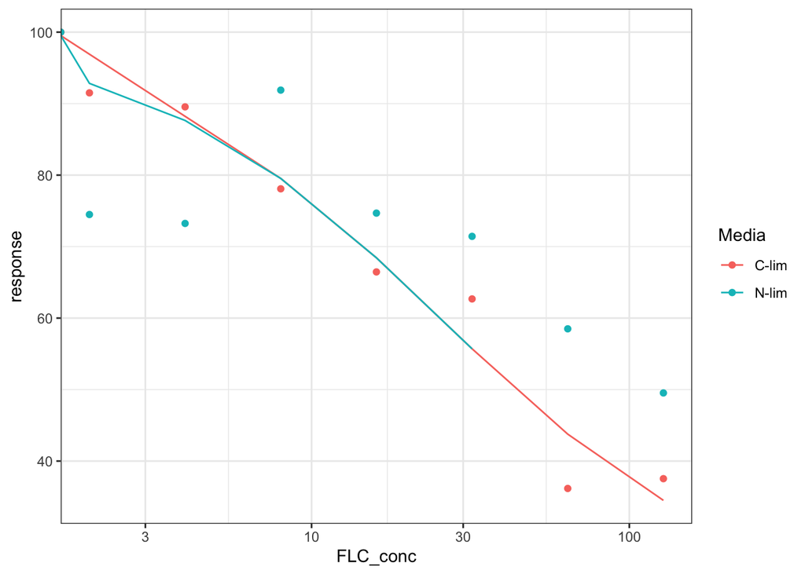

```r
dose=c(0,8,16,32,64,128,0,2,4,8,16,32)
condition=c("C-lim","C-lim","C-lim","C-lim","C-lim","C-lim","N-lim","N-lim","N-lim","N-lim","N-lim","N-lim")
predicted_data = data.frame(
  FLC_conc = dose, Type = condition
)

predict(model,newdata=predicted_data) -> predicted_data$prediction

drc_per_condition %>%
  ggplot(aes(x=FLC_conc,y=response,colour=Media)) + geom_point() + scale_x_log10() + theme_bw() + geom_line(data=predicted_data,aes(x=FLC_conc,y=prediction,colour=Type))
```

```r
#ADDED APR 2025
# Controlonly3=predicted_data[predicted_data$Type=="Control",]
#
# Control_doseresponsemodel=
#   Controlonly2 %>%
#   ggplot(aes(x=FLC_conc,y=response,colour=Type)) + geom_point() + scale_x_log10() + theme_bw() + geom_line(data=Controlonly3,aes(x=FLC_conc,y=prediction)) + ggtitle("IC50 model (line) with actual data (points)") + geom_vline(xintercept=23.1,linetype="dashed")
#
# Control_doseresponsemodel
#
# ggsave("Control_doseresponsemodel.pdf", Control_doseresponsemodel, device="pdf")
```